# Introduction to data.table

data cleaning

data.table

dplyr

R

To data.table or dplyr? That is the question.

Erika Duan  
01-30-2021

# Introduction

Programming languages are still human constructs. They hold sway when they are utilised *en mass*, like Python for machine learning, and user factions may emerge if very different ways of doing the same thing concurrently exist.

In R, this can manifest in the form of `data.table` versus `dplyr` debates. [^1]

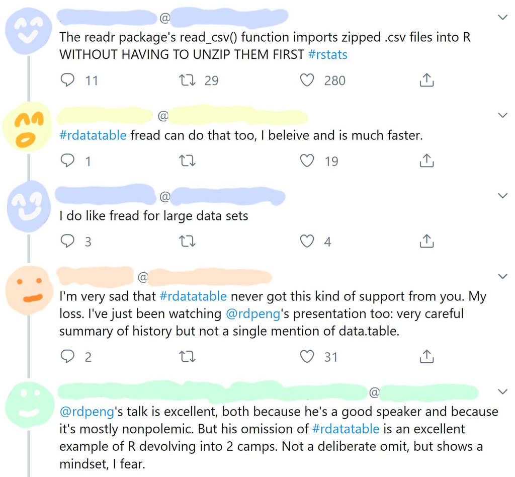

Both R packages contain a comprehensive stack of functions for data wrangling. The tidyverse `dplyr` approach emphasises code readability whilst `data.table` scales complex manipulations of large datasets very efficiently. You can compare the efficiency of `data.table` versus other data wrangling packages on large datasets [here](https://h2oai.github.io/db-benchmark/).

Whilst I prefer to use `dplyr` on small datasets where `data.table` efficiency gains are negligible, I recommend using `data.table` when:

- You are using very large datasets (datasets over 0.5 million rows) **and**
- You need to use **group by** operations for data cleaning or feature engineering.

Let’s explore this for ourselves.

```r
# Load required packages -------------------------------------------------------
if (!require("pacman")) install.packages("pacman")
pacman::p_load(here,
               lobstr, # Trace objects in memory
               ids, # Generate random ids
               DT, # Create interactive tables
               tidyverse,
               data.table,
               microbenchmark)
```

# Create a test dataset

Imagine you have a dataset describing how students are engaging with online courses:

- Each student has a unique ID.
- There are 5 different online platforms, labelled **A**, **B**, **C**, **D** and **E**.
- Students have the option of taking different courses within the same platform or switching to a different platform.
- Platform start dates are recorded when the student starts the first course on a new platform.
- Platform end dates are recorded when the student exits a platform.
- Course start dates are recorded when the student starts a course.
- Course end dates are recorded when the student exits a course.

| id | platform | course | platform_start_date | platform_end_date | course_start_date | course_end_date |
| --- | --- | --- | --- | --- | --- | --- |
| 00007f23 | D | metal_welding | 2016-03-09 | 2016-04-20 | 2016-03-09 | 2016-04-20 |
| 00007f23 | E | website_design | 2016-06-23 | 2016-08-01 | 2016-06-23 | 2016-08-01 |
| 00007f23 | E | fitness_training | 2017-05-21 | 2017-07-17 | 2017-05-21 | 2017-07-17 |
| 00007f23 | A | metal_welding | 2017-11-29 | 2018-01-07 | 2017-11-29 | 2018-01-07 |
| 00007f23 | C | bread_baking | 2018-03-03 | 2018-04-22 | 2018-03-03 | 2018-04-22 |
| 00007f23 | A | UX_design | 2018-09-05 | 2018-11-11 | 2018-09-05 | 2018-11-11 |
| 000080c8 | D | contemporary_dance | 2016-10-31 | 2016-11-09 | 2016-10-31 | 2016-11-09 |
| 000080c8 | B | fitness_training | 2018-12-04 | 2019-01-25 | 2018-12-04 | 2019-01-25 |
| 0000ba9c | E | website_design | 2016-10-07 | 2016-11-30 | 2016-10-07 | 2016-11-30 |
| 0000ba9c | D | R_beginner | 2017-08-08 | 2017-09-21 | 2017-08-08 | 2017-09-21 |

[output cut: 2 more lines]

**Note:** The code used to create this dataset can be accessed from my github repository [here](https://github.com/erikaduan/R-tips/blob/master/03_blog_posts/2020-04-07_data-table-versus-dplyr/2020-04-07_data-table-versus-dplyr.md).

# Principles of `data.table`

In R, datasets exist as `data.frame` type objects. To apply `data.table` functions on a dataset, we need to convert a `data.frame` into a `data.table` object using `setDT()`.

This function is flexible as it converts a `data.frame` by reference (i.e. without creating a duplicate `data.table` copy) and assigns both `data.table` and `data.frame` classes to the converted object.

```r
# Convert data frame into data.table -------------------------------------------
class(student_courses)
```

```
#> [1] "tbl_df"     "tbl"        "data.frame"
```

```r
mem_used()
```

```
#> 222,639,352 B
```

```r
# Track object assignment in memory
tracemem(student_courses)
```

```
#> [1] "<0000022B07B7AB70>"
```

```r
setDT(student_courses) # data.table is assigned to a new location in memory
```

```
#> tracemem[0x0000022b07b7ab70 -> 0x0000022b047a8478]: as.list.data.frame as.list vapply vapply_1i setDT
```

```r
untracemem(student_courses)

mem_used()
```

```
#> 242,674,176 B
```

```r
# Note that computer memory has not doubled following setDT()

class(student_courses)
```

```
#> [1] "data.table" "data.frame"
```

## `data.table` query structure

A `data.table` query is structured in the form `DT[i, j, by]` where:

- Data selection (i.e. filtering or sorting rows) is performed in the `i` placeholder.
- Data column selection or creation is performed in the `j` placeholder.
- Grouping data by variable(s) is performed in the `by` placeholder.

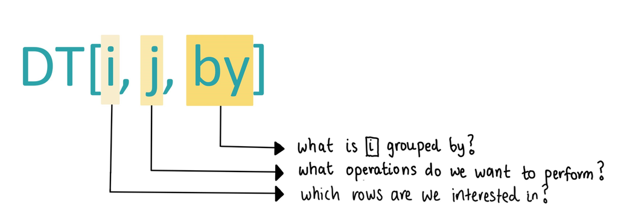

## `data.table` efficiency gains

There are a few reasons why `data.table` operations are fast:

- Many of its operations, including grouping, reading and writing, are parallelised by default.
- `data.table` automatically creates a secondary index (or key) of the columns used to subset data, so that subsequent operations on the same column are much faster.
- `data.table` has a much faster `order()` function, which is also utilised for the evaluation of groupings.
- You can use the operator `:=` to add, delete or modify columns in place, which is a faster alternative to R’s default copy-on-modify behaviour.

```r
# Create data.frame and data.table objects -------------------------------------
df <- data.frame(id = seq(1:5),
                 letter = letters[1:5])

dt <- as.data.table(df)

# Update data.frame column using copy-on-modify --------------------------------
df_2 <- df %>%
  mutate(letter = toupper(letter))

# The new data frame is a shallow copy of the original data frame as
# only modified columns are newly created in memory.

ref(df, df_2)
```

```
#> o [1:0x22b03b6c998] <df[,2]>
#> +-id = [2:0x22b7f3f6350] <int>
#> \-letter = [3:0x22b0c54b328] <chr>
```

```
#> o [4:0x22b03b90e78] <df[,2]>
#> +-id = [2:0x22b7f3f6350]
#> \-letter = [5:0x22b05f9b890] <chr>
```

```r
# Update data.table column by reference ----------------------------------------
obj_addr(dt)
```

```
#> [1] "0x22b016ed030"
```

```r
dt[, letter := toupper(letter)]

obj_addr(dt)
```

```
#> [1] "0x22b016ed030"
```

**Note:** You do not need to assign datasets to names when modifying by reference using the `:=` operator.

# Filter data

## Using `dplyr`

The basic syntax for filtering data is very similar for `dplyr` and `data.table`.

```r
# Filter student_courses using dplyr -------------------------------------------
# Filter by platform A
student_courses %>%
  filter(platform == "A")

# Filter by all platforms excepting A
student_courses %>%
  filter(platform != "A")

# Filter by platforms A and C
student_courses %>%
  filter(platform %in% c("A", "C"))

# Using a comma is a substitute for the condition 'and'
student_courses %>%
  filter(id == "00007f23",
         between(platform_start_date, "2017-01-01", "2017-12-31"))

# Filter by a variable using regex
student_courses %>%
  filter(str_detect(course, "^R_"))
```

In `dplyr` version >= 1.0.0, the functions `if_any()` and `if_all()` can be incorporated to filter across multiple columns.

```r
# Filter across multiple rows using dplyr --------------------------------------
# Filter across all date columns where all columns are TRUE
student_courses %>%
  filter(if_all(ends_with("_date"), ~between(., "2017-01-01", "2017-12-31")))

# Filter across all date columns where at least one column is TRUE
student_courses %>%
  filter(if_any(ends_with("_date"), ~between(., "2017-01-01", "2017-12-31")))
```

**Note:** The function `between()` is equivalent to `lower <=x & x <= upper` when `incbounds=TRUE` and `lower < x & y < upper` when `incbounds=FALSE`.

## Using `data.table`

A minor difference is that `data.table` also contains a list of helper functions with optimised performance for filtering on specific data types like characters or integers.

```r
# Filter student_courses using data.table --------------------------------------
# Filter by platform A
student_courses[platform == "A"]

# Filter by all platforms excepting A
student_courses[platform != "A"]

# Operator %chin% is equivalent to but faster than %in%
student_courses[platform %chin% c("A", "C")]

# Operator %between% or data.table::between() searches across a range of values
student_courses[id == "00007f23" &
                platform_start_date %between% c("2017-01-01", "2017-12-31")]

# Operator %like% allows you to search for a pattern in a character vector
student_courses[course %like% "R_"]
```

Currently, `dplyr` offers more versatility than `data.table` in terms of filtering across multiple columns. A readable `data.table` equivalent to `if_all()` currently does not exist and the equivalent to `if_any` [can be solved using `get()`](https://stackoverflow.com/questions/48641680/filter-data-table-on-same-condition-for-multiple-columns) to return the value of multiple columns.

```r
# Filter across multiple rows using data.table ---------------------------------
# Filter across all date columns where at least one column is TRUE
date_cols <- str_subset(colnames(student_courses), "_date$")
student_courses[get(date_cols) %between% c("2017-01-01", "2017-12-31"), .SDcols = date_cols]

# get(date_cols) == condition is equivalent to if_any(condition) == TRUE
```

## Benchmark data filtering

You can use the R package `microbenchmark` to measure code performance. [^2]

The function `microbenchmark()` runs each expression 100 times by default with the argument `times = 100L`. It outputs summary statistics on how long it takes to evaluate a single expression.

Table 1: Units: milliseconds

| expr | min | lq | mean | median | uq | max | neval |
| --- | --- | --- | --- | --- | --- | --- | --- |
| filter(student_courses, platform == “A”) | 9.0241 | 9.89670 | 17.45452 | 10.77120 | 13.19065 | 188.7689 | 100 |
| student_courses[platform == “A”] | 8.4162 | 9.12350 | 11.79773 | 9.60965 | 10.48005 | 35.0547 | 100 |
| filter(student_courses, platform %in% c(“A”, “C”)) | 12.1439 | 13.05705 | 20.04014 | 14.65670 | 33.03505 | 41.0345 | 100 |
| student_courses[platform %chin% c(“A”, “C”)] | 13.4523 | 14.65795 | 19.35104 | 15.47045 | 16.69780 | 46.3068 | 100 |
| filter(student_courses, str_detect(course, “^R_”)) | 83.2341 | 88.54035 | 97.67838 | 91.93555 | 102.11460 | 214.3023 | 100 |
| student_courses[course %like% “R_”] | 53.7119 | 57.01275 | 62.96518 | 58.66400 | 62.27945 | 224.8972 | 100 |
| dplyr_filter_if_any | 34.7018 | 37.33390 | 49.85545 | 41.14285 | 59.23520 | 215.8179 | 100 |
| data.table_filter_get_cols | 13.6371 | 14.82760 | 21.16597 | 15.69680 | 17.09135 | 186.9853 | 100 |

# Sort data

## Using `dplyr`

Sorting a data frame can be computationally expensive when multiple variables need to be ranked. This is why I recommending sorting your dataset once, right after basic data cleaning operations have been performed.

```r
# Sort student_courses using dplyr ---------------------------------------------
student_courses %>%
  arrange(course_start_date)

student_courses %>%
  arrange(platform,
          id,
          desc(platform_start_date))

# Sorting by a descending date ranks the most recent date as first
```

## Using `data.table`

In `data.table`, sorting is also performed inside `i` of `DT[i, j, by]`. Using the operator `-` in front of a variable allows sorting by descending order.

```r
# Sort student_courses using data.table ----------------------------------------
student_courses[order(course_start_date)]

student_courses[order(platform,
                      id,
                      -platform_start_date)]

# You can also order columns in place using setorder()
setorder(student_courses,
         id,
         platform_start_date,
         course_start_date)
```

## Benchmark data sorting

Table 2: Units: milliseconds

| expr | min | lq | mean | median | uq | max | neval |
| --- | --- | --- | --- | --- | --- | --- | --- |
| arrange(student_courses, course_start_date) | 27.2534 | 35.2252 | 44.51070 | 49.7276 | 52.7478 | 61.6616 | 25 |
| student_courses[order(course_start_date)] | 54.8829 | 62.0147 | 70.32617 | 69.7907 | 72.0628 | 96.8317 | 25 |
| arrange(student_courses, platform, id, desc(platform_start_date)) | 5605.0036 | 5654.6456 | 5702.51392 | 5682.9645 | 5712.8049 | 6182.9437 | 25 |
| student_courses[order(platform, id, -platform_start_date)] | 119.1436 | 125.0282 | 134.31395 | 130.4740 | 144.8021 | 160.8236 | 25 |

# Select data columns

## Using `dplyr`

In `dplyr`, performing operations on a tibble will always return another data frame, unless you explicitly use `pull()` to extract a column as a vector.

```r
# Select column(s) using dplyr -------------------------------------------------
student_courses %>%
  select(id)

student_courses %>%
  select(c(id, platform, course))

# Select columns(s) using regex
student_courses %>%
  select(contains("date", ignore.case = F))

# Output data.frame with select() ----------------------------------------------
student_courses %>%
  select(id) %>%
  class()
```

```
#> [1] "data.table" "data.frame"
```

```r
# Output vector with pull() ----------------------------------------------------
student_courses %>%
  pull(id) %>%
  class()
```

```
#> [1] "character"
```

```r
student_courses %>%
  .[["id"]] %>%
  class()
```

```
#> [1] "character"
```

## Using `data.table`

In `data.table`, column selection is performed inside `j` of `DT[i, j, by]` and returns a `data.table` if you wrap column names inside a list.

```r
# Select column(s) using data.table --------------------------------------------
student_courses[,
                .(id)]

student_courses[,
                .(id,
                  platform,
                  course)]

# Select column(s) using regex
str_subset(colnames(student_courses), "date")
```

```
#> [1] "platform_start_date" "platform_end_date"   "course_start_date"   "course_end_date"
```

```r
student_courses[,
                str_subset(colnames(student_courses), "date"),
                with = F]

# Output data frame by wrapping column names inside a list ---------------------
class(student_courses[, .(id)])
```

```
#> [1] "data.table" "data.frame"
```

```r
# Output vector with [[x]] -----------------------------------------------------
class(student_courses[, id])
```

```
#> [1] "character"
```

```r
class(student_courses[["id"]])
```

```
#> [1] "character"
```

**Note:** In `data.table`, `.(cols)` is just a shorthand for `list(cols)` and is used to list columns in the `j` placeholder.

## Benchmark column selection

Interestingly, the benchmark below shows that `dplyr` is slightly faster than `data.table` for column selections.

Table 3: Units: milliseconds

| expr | min | lq | mean | median | uq | max | neval |
| --- | --- | --- | --- | --- | --- | --- | --- |
| select(student_courses, c(id, platform, course)) | 1.8944 | 2.32380 | 2.633437 | 2.48395 | 2.82525 | 5.3393 | 100 |
| student_courses[, .(id, platform, course)] | 4.3514 | 5.12335 | 14.512512 | 7.25425 | 24.44105 | 136.2222 | 100 |
| select(student_courses, contains(“date”, ignore.case = F)) | 1.2884 | 1.55195 | 1.789318 | 1.72585 | 1.97540 | 3.0404 | 100 |
| student_courses[, grep(“date”, names(student_courses), value = T), with = F] | 1.3837 | 1.75865 | 7.824120 | 2.72795 | 3.90910 | 128.7633 | 100 |

# Column creation

## Using `dplyr`

As `dplyr` objects are data frames, a shallow `data.frame` copy is created whenever a column is modified using `mutate()`.

```r
# Create column(s) using dplyr -------------------------------------------------
# Create new columns from existing variables
student_courses %>%
  mutate(platform_dwell_length = platform_end_date - platform_start_date,
         platform_start_year = as.numeric(str_extract(platform_start_date, "^.{4}(?!//-)")))

# Create column(s) with multiple conditions using dplyr ------------------------
str_subset(unique(student_courses$course), "^R_")
```

```
#> [1] "R_beginner"     "R_advanced"     "R_intermediate"
```

```r
str_subset(unique(student_courses$course), "^Python_")
```

```
#> [1] "Python_intermediate" "Python_advanced"     "Python_beginner"
```

```r
student_courses %>%
  mutate(studied_programming = case_when(str_detect(course, "^R_") ~ "Studied R",
                                         str_detect(course, "^Python_") ~ "Studied Python",
                                         TRUE ~ "No"))
```

In `dplyr` version >= 1.0.0, you can use `mutate()` in combination with `across()` to apply transformations across one or multiple columns.

```r
# Create multiple columns using dplyr ------------------------------------------
# across() accepts function names or ~function(.x) syntax
student_courses %>%
  mutate(across(c(id, platform, course, course), ~toupper(.x)))

# where() can be used inside across() to select columns by type
student_courses %>%
  mutate(across(where(is.character), ~toupper(.x)))
```

In contrast to `mutate()`, `transmute()` only returns the transformed column(s) of interest.

```r
# Create and only return column(s) using dplyr ---------------------------------
student_courses %>%
  transmute(across(c(id, platform, course), ~toupper(.x))) %>%
  ncol()
```

```
#> [1] 3
```

```r
student_courses %>%
  mutate(across(c(id, platform, course, course), ~toupper(.x))) %>%
  ncol()
```

```
#> [1] 7
```

## Using `data.table`

Data frame outputs are slightly different in `data.table`:

- Column transformations are always modified in place using the operator `:=`.
- Multiple columns can be concurrently modified, as long as the newly created columns do not depend on each other.
- Use subassignment with `=` (instead of `:=`) to extract only the columns transformed inside `j` of `DT[i, j, by]`.

```r
# Create column(s) using data.table --------------------------------------------
student_courses[,
                `:=` (platform_dwell_length = platform_end_date - platform_start_date,
                      platform_start_year = str_extract(platform_start_date, "^.{4}(?!//-)"))]

student_courses[,
                platform_start_year := as.numeric(platform_start_year)]

# Create column(s) with multiple conditions using data.table -------------------
student_courses[,
                studied_programming := fcase(
                  str_detect(course, "^R_"), "Studied R",
                  str_detect(course, "^Python_"), "Studied Python",
                  default = "No")]

# Remove newly created columns using data.table --------------------------------
# Column(s) can be removed by assignment as NULL variable(s)
student_courses[,
                c("platform_dwell_length",
                  "platform_start_year",
                  "studied_programming") := NULL]
```

In `data.table`, the [solution](https://stackoverflow.com/questions/68055613/transform-multiple-columns-and-return-all-columns-using-data-table-in-r/68055663#68055663) to creating multiple columns is to specify columns of interest into `.SDcols` and then loop through each column using `lapply(function)`.

```r
# Create multiple columns using data.table -------------------------------------
# (col_vector) or c("x", "y") := lapply(...) modifies all columns in place
cols <- c("id", "platform", "course")
student_courses[,
                (cols) := lapply(.SD, toupper),
                .SDcols = cols]

# Equivalent code
student_courses[,
                c("id", "platform", "course") := lapply(.SD, toupper),
                .SDcols = c("id", "platform", "course")]
```

```r
# Use subassignment with `=` to return only transformed columns ----------------
dt_subset <- student_courses[,
                             .(id = toupper(id),
                               platform = toupper(platform),
                               course = toupper(course))]

ncol(dt_subset)
```

```
#> [1] 3
```

```r
# Equivalent code using .SDcols and lapply()
dt_subset <- student_courses[,
                             lapply(.SD, toupper),
                             .SDcols = cols]
```

## Benchmark column creation

Table 4: Units: milliseconds

| expr | min | lq | mean | median | uq | max | neval |
| --- | --- | --- | --- | --- | --- | --- | --- |
| mutate(student_courses, platform_dwell_length = platform_end_date - platform_start_date) | 5.0602 | 6.90770 | 25.55252 | 8.26925 | 9.68500 | 173.8566 | 100 |
| student_courses[, `:=`(“platform_dwell_length”, platform_end_date - platform_start_date)] | 3.6370 | 5.19895 | 25.54544 | 6.33755 | 7.82895 | 171.3265 | 100 |
| dplyr_case_when | 225.6839 | 249.70800 | 269.89679 | 267.90020 | 279.05350 | 458.1452 | 100 |
| data.table_fcase | 195.9269 | 208.36720 | 221.09485 | 213.40350 | 227.35105 | 377.5954 | 100 |
| dplyr_mutate_across | 371.1676 | 385.88140 | 404.99245 | 396.43500 | 407.44485 | 499.2400 | 100 |
| data.table_lapply_SDcols | 366.4740 | 386.23370 | 405.55840 | 392.76045 | 411.39315 | 497.5348 | 100 |

# Simple group by operations

## Using `dplyr`

Summarising by group is also where `data.table` significantly outperforms `dplyr`. A grouping is specified using the `group_by()` function in `dplyr`.

```r
# Find total number of courses per student via dplyr ---------------------------
student_courses %>%
  group_by(id) %>%
  summarise(total_courses = n()) %>%
  ungroup()

# Code above is also equivalent to using count()
student_courses %>%
  count(id)

# Find total number of distinct courses per student via dplyr ------------------
student_courses %>%
  group_by(id) %>%
  summarise(total_distinct_courses = n_distinct(course)) %>%
  ungroup()

# Find the first course studied per student and platform via dplyr -------------
student_courses %>%
  group_by(id, platform) %>% # Group by two variables
  filter(row_number() == 1L) %>% # Return the first row from each group
  ungroup()
```

## Using `data.table`

In `data.table`, a grouping is specified inside the `by` placeholder of `DT[i, j, by]`.

```r
# Find total number of courses per student via data.table ----------------------
student_courses[,
                .(total_courses = .N),
                by = id]

# Find total number of distinct courses per student via data.table -------------
student_courses[,
                .(total_distinct_courses = length(unique(course))),
                by = id]

# uniqueN(x) is a data.table function equivalent to length((unique(x))
student_courses[,
                .(total_distinct_courses = uniqueN(course)),
                by = id]

# Find the first course studied per student and platform via data.table --------
student_courses[,
                .SD[1L],
                by = .(id, platform)]
```

## Benchmark simple group by operations

Group by operations are significantly faster in `data.table` than `dplyr`.

Table 5: Units: milliseconds

| expr | min | lq | mean | median | uq | max | neval |
| --- | --- | --- | --- | --- | --- | --- | --- |
| student_courses %>% group_by(id) %>% summarise(total_courses = n()) | 2253.7473 | 2416.8814 | 2848.64304 | 2498.8589 | 3270.4622 | 4162.8841 | 10 |
| student_courses[, .(total_courses = .N), by = id] | 46.7541 | 50.0241 | 60.37993 | 53.6803 | 70.2789 | 83.9196 | 10 |
| student_courses %>% group_by(id) %>% summarise(total_distinct_courses = n_distinct(course)) | 4025.6523 | 4237.2057 | 4937.93044 | 4647.9254 | 5331.3878 | 6326.4315 | 10 |
| student_courses[, .(total_distinct_courses = length(unique(course))), by = id] | 847.1269 | 879.6714 | 1034.19212 | 971.1114 | 1218.1229 | 1356.3699 | 10 |
| student_courses[, .(total_distinct_courses = uniqueN(course)), by = id] | 6262.0236 | 6343.8344 | 7207.72692 | 6594.7426 | 7264.5609 | 10044.3720 | 10 |
| student_courses %>% group_by(id, platform) %>% filter(row_number() == 1L) | 7872.6713 | 8103.4138 | 9778.25568 | 9260.2453 | 10907.8334 | 13687.8050 | 10 |
| student_courses[, .SD[1L], by = .(id, platform)] | 69.1016 | 71.2565 | 78.52564 | 74.1029 | 78.2506 | 120.5737 | 10 |

**Note:** Not all `data.table` functions outperform their base R or `dplyr` equivalents. The `data.table` `uniqueN(x)` function is much slower than `length(unique(x))`.

# Summary

# Other resources

- A [stack overflow discussion](https://stackoverflow.com/questions/21435339/data-table-vs-dplyr-can-one-do-something-well-the-other-cant-or-does-poorly/27840349#27840349) about the best use cases for `data.table` versus `dplyr`.
- A great side-by-side comparison of `data.table` versus `dplyr` functions from a [blog post by Atrebas](https://atrebas.github.io/post/2019-03-03-datatable-dplyr/).
- A list of advanced `data.table` operations and tricks from a [blog post by Andrew Brooks](http://brooksandrew.github.io/simpleblog/articles/advanced-data-table/).
- An explanation of how `data.table` modifies by reference from a [blog post by Tyson Barrett](https://tysonbarrett.com//jekyll/update/2019/07/12/datatable/).
- A benchmark of `dplyr` versus `data.table` functions from a [blog post by Tyson Barrett](https://tysonbarrett.com/jekyll/update/2019/10/06/datatable_memory/)
[^1]: I am extremely thankful for encountering these Twitter debates, as they helped draw more attention to `data.table` usage.
[^2]: For accurate benchmarking, you need to separately run, save and print `microbenchmark()` outputs rather than directly knitting results.